# Análisis de patrón de puntos en R

Geoestadística i Tècniques d’Observació Global

Author

Aitor Ameztegui & Pere Gelabert (UdL)

Published

November 9, 2026

# Introducción

Como vimos en clase, un conjunto de datos de patrones de puntos contiene una serie de eventos (es decir, objetos de interés) que ocurren en una región de estudio definida. Estos eventos pueden representar cualquier cosa con una ubicación medible, incluyendo árboles, nidos de animales, ubicaciones de estaciones meteorológicas, ocurrencias de delitos, etc. sin que exista necesariamente una variable de interés. Es decir, lo que nos interesa es la ubicación de los eventos más que su valor.

Como hemos visto, los patrones de puntos tienen propiedades de **primer orden**, que están relacionadas con la *intensidad* (es decir, la densidad) de los sucesos en la región de estudio, y propiedades de **segundo orden**, que están relacionadas con la *dependencia espacial* (es decir, la disposición espacial) de los sucesos en la zona de estudio.

**Objetivo**

El objetivo del lab de hoy es aprender algunos enfoques estadísticos espaciales para caracterizar las propiedades de primer y segundo orden de un patrón de puntos.

**Datos y librerías**

Para realizar un análisis de patrón de puntos utilizaremos fundamentalmente el paquete de R `spatstat`. Lo primero que debemos hacer es instalarlo - a no ser que ya lo tengamos instalado - y cargarlo:

```r
#install.packages("spatstat") (sólo si no está ya instalado)
library(spatstat)
```

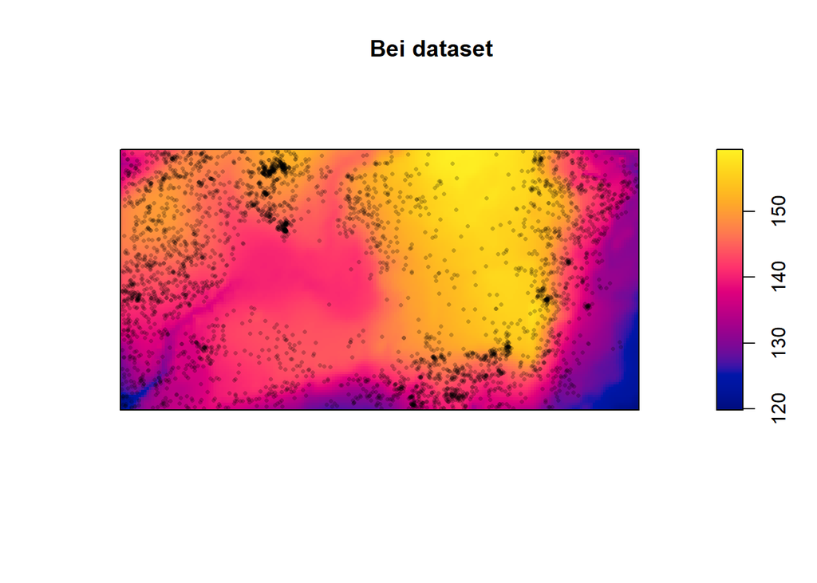

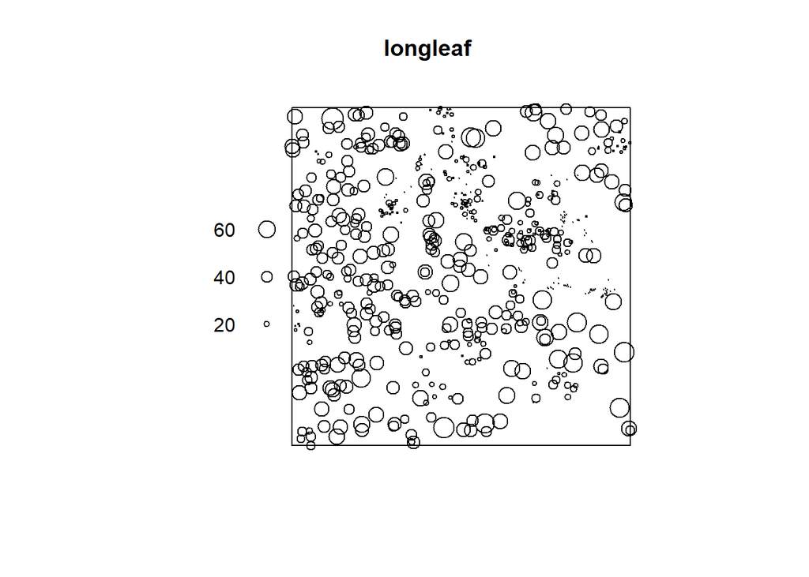

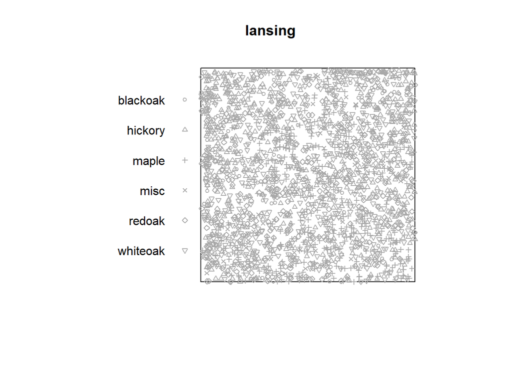

**NOTA:** al plotear los ficheros precargados del paquete `spatstat` podemos definir algunos parámetros de los puntos, como hacemos con un scatterplot normal. En este caso hemos modificado el tipo de puntos, su tamaño y el color, mediante los comandos `pch` ,`cex`, y `cols`, respectivamente. Podéis encontrar más información de como modificar los parámetros de un gráfico [aquí](https://www.statmethods.net/advgraphs/parameters.html)

# Familiarizándose con los objetos `ppp`

El paquete `spatstat` usa una clase específica de objetos de R llamados ppp (planar point pattern). Los datos que vamos a usar, que se cargan automáticamente al instalar `spatstat` son objetos de esa clase.

Examinemos el dataset `bei`. Para ello devemos abrirlo tecleando:

```r
data(bei)
```

Y podemos ver su contenido tecleando su nombre:

```r
bei
```

```
Planar point pattern: 3604 points
window: rectangle = [0, 1000] x [0, 500] metres
```

Vemos que es un archivo de patrón de puntos con 3604 observaciones. El objeto `ppp` también contiene información sobre la región que contiene los eventos. En este caso, es un rectángulo con un rango de coordenadas $x$ de entre 0 y 1000 , y un rango de $y$ de entre 0 y 500, y las unidades en metros.

Podemos visualizar el objeto `bei` escribiendo:

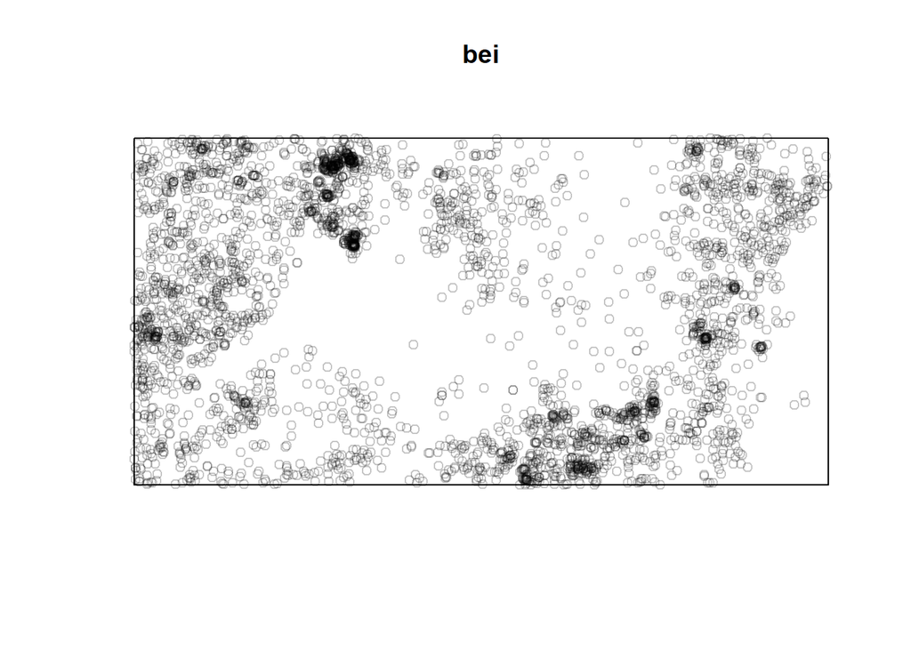

```r
plot(bei)
```

Igual que hemos hecho hasta ahora, podemos cambiar el color, formato de los puntos, y otras características del plot

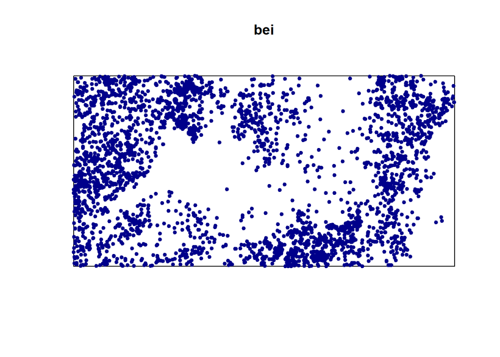

```r
plot(bei, pch = 20, cols = "dark blue")
```

# Estadísticas descriptivas (centrografía)

Los estadísticos centrográficos son estadísticos descriptivos simples que se utilizan a menudo para el análisis exploratorio de datos en la estadística espacial. Los estadísticos centrográficos, como la posición central, la desviación estándar, la elipse de desviación estándar pueden utilizarse para ayudar a la caracterización de la distribución espacial de los conjuntos de datos referenciados espacialmente.

En $R$ podemos calcular por ejemplo la posición media y mediana de los puntos, lo haremos con el dataset `bei`:

```r
x_media <- mean(bei$x)
y_media <- mean(bei$y)

x_mediana <- median(bei$x)
y_mediana <- median(bei$y)
```

y representarlo gráficamente sobre los puntos:

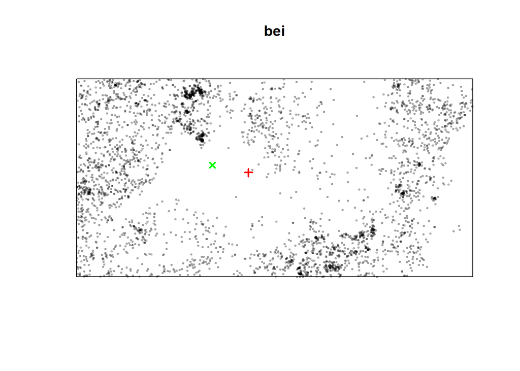

```r
plot(bei, pch = 20, cex = 0.5)
points(x_media, y_media, col = "red", pch = 3, lwd=2)
points(x_mediana, y_mediana, col = "green", pch = 4, lwd= 2)
```

También podemos calcular la desviación estándard y usarla para construir un círculo con ese radio:

```r
x_sd <- sd(bei$x)
y_sd <- sd(bei$y)

sd_bei = mean(x_sd, y_sd)
```

Y plotearlo, pero para dibujar un círculo necesitamos la función `draw.circle()` del paquete `plotrix`:

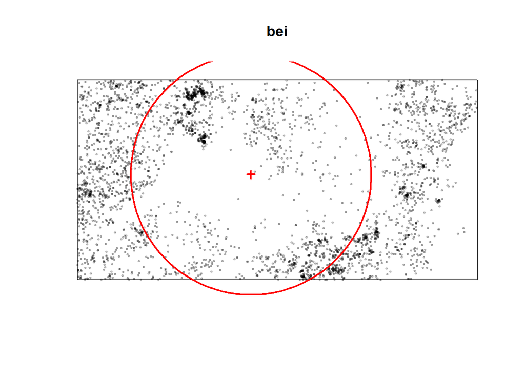

```r
library(plotrix)
plot(bei, pch = 20, cex = 0.5)
points(x_media, y_media, col = "red", pch = 3, lwd=2)
draw.circle(x= x_media, y = y_media, border = "red",
            radius = sd_bei, lwd = 2)
```

En ArcGis Pro y QGis también existen funciones para realizar este tipo de análisis y visualización. En concreto, podemos usar las funciones `mean center`, o `standard distance` dentro del toolbox `Spatial Statistics`. Incluso podemos dibujar la elipse de desviación estandard mediante la función `directional distribution`.

# Análisis basados en densidad

## Intensidad global

Como hemos visto en la teoría, la intensidad de un proceso expresado en patrón de puntos puede calcularse a través de la siguiente ecuación:

$\lambda = {n}/{a}$

donde $\lambda$ es la intensidad, $n$ es el número de observaciones y $a$ la superficie considerada como área de estudio. Conociendo estos dos parámetros podemos calcular la intensidad:

El número de observaciones es un parámetro del objeto `ppp`:

```r
n_obs <- bei$n
```

y el área lo podemos obtener también de un objeto `ppp`:

```r
bei$window
```

```
window: rectangle = [0, 1000] x [0, 500] metres
```

```r
superf <- area(bei$window)
superf
```

```
[1] 5e+05
```

Por tanto la intensidad será:

```r
intens_bei <- n_obs / superf
intens_bei
```

```
[1] 0.007208
```

Sin embargo, `spatstat` ya proporciona una función `summary()` que nos proporciona información de la muestra, entre ella la intensidad:

```r
summary(bei)
```

```
Planar point pattern:  3604 points
Average intensity 0.007208 points per square metre

Coordinates are given to 1 decimal place
i.e. rounded to the nearest multiple of 0.1 metres

Window: rectangle = [0, 1000] x [0, 500] metres
Window area = 5e+05 square metres
Unit of length: 1 metre
```

También podemos acceder a la intensidad de forma directa:

```r
summary(bei)$intensity
```

```
[1] 0.007208
```

## Análisis de cuadrículas

Calcular la intensidad global de un proceso de puntos puede tener interés para comparar dos muestras diferentes, o cambios temporales, pero para caracterizar de forma más completa la muestra debemos determinar cómo varía la intensidad en el espacio. Una forma sencilla es a través del conteo por cuadrículas. Consiste en dividir el área de estudio en una serie de cuadrículas de tamaño constante, y calcular la intensidad en cada una de ellas. El resultado nos puede ayudar a determinar si el patrón de eventos está distribuido regularmente o de manera agrupada. `spatstat` contiene una función (`quadratcount()`) que nos permite calcularlo de manera muy sencilla.

```r
q <- quadratcount(bei, nx= 4, ny = 4)
q
```

```
           x
y           [0,250) [250,500) [500,750) [750,1e+03]
  [375,500]     368       506        64         287
  [250,375)     298       171        66         194
  [125,250)     324        27        54         178
  [0,125)       220       138       589         120
```

También podemos visualizarlo:

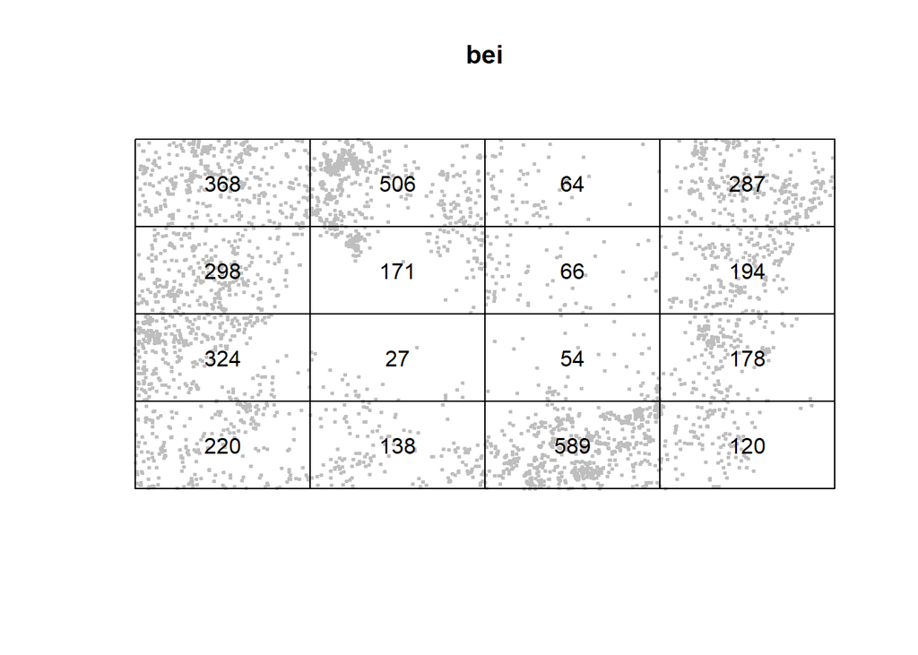

```r
plot(bei, cols = "gray", pch = 20, cex = 0.5)
plot(q, add = T)
```

En las sesiones teóricas vimos que la hipótesis nula en el caso de una distrbución de puntos es que estos se encuentran repartidos aleatoriamente en las cuadrículas. Sabiendo la intensidad de la muestra, podemos generar una serie de puntos aleatorios, que sigan una distribución de Poisson. Este numero de eventos, que sería el esperado en una muestra que cumpla la aleatoriedad, se compara con lo que realmente tenemos (observado) mediante un test de Chi-cuadrado, que en `spatstat` viene implementado en la función `quadrat.test()`, que se puede usar con el objeto `ppp` o con el resultado de `quadratcount()`:

```r
quadrat.test(bei, nx= 4, ny = 4)
```

```
    Chi-squared test of CSR using quadrat counts

data:  bei
X2 = 1754.6, df = 15, p-value < 2.2e-16
alternative hypothesis: two.sided

Quadrats: 4 by 4 grid of tiles
```

```r
quadrat.test(q)
```

```
    Chi-squared test of CSR using quadrat counts

data:
X2 = 1754.6, df = 15, p-value < 2.2e-16
alternative hypothesis: two.sided

Quadrats: 4 by 4 grid of tiles
```

En este caso, vemos que el p-valor es claramente inferior a 0.05, por lo que podemos rechazar la hipótesis nula, y por tanto decidir que los puntos no se distribuyen aleatoriamente. También podemos ver este resultado de manera gráfica:

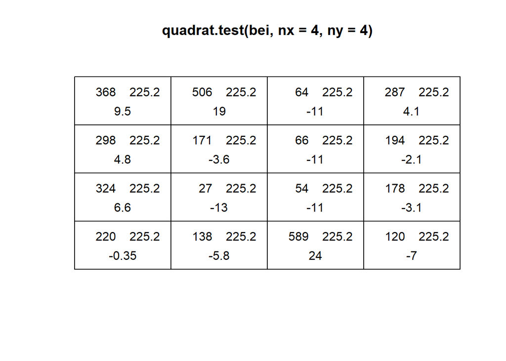

```r
plot(quadrat.test(bei, nx = 4, ny = 4))
```

Podemos por supuesto cambiar el número de cuadrículas a nuestro antojo:

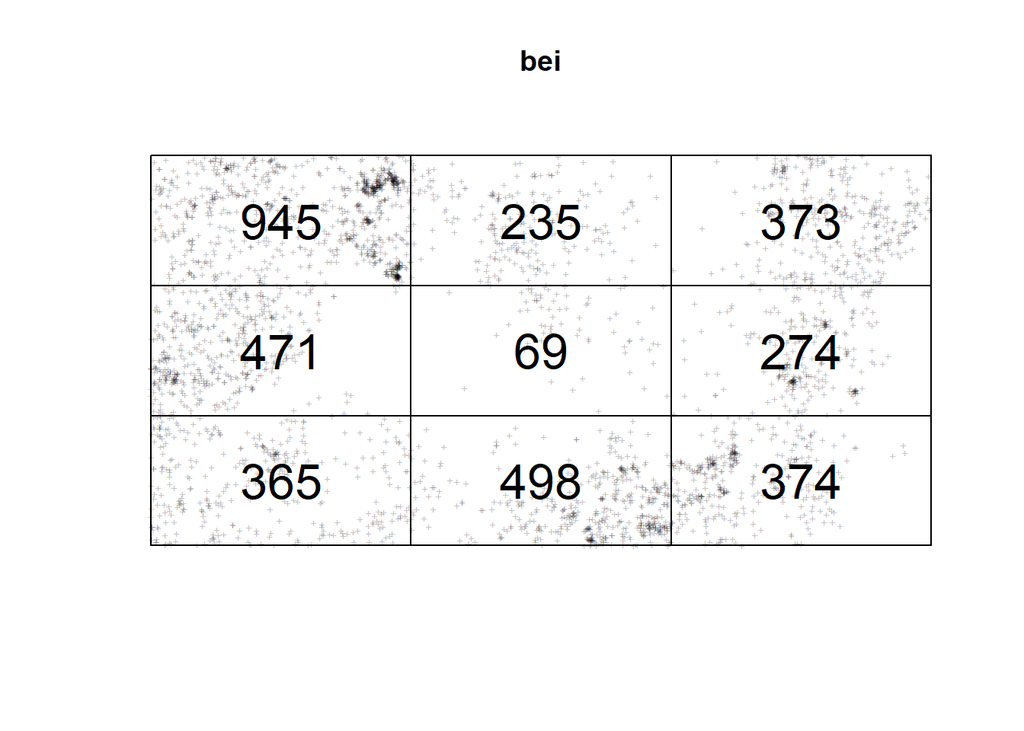

```r
Q9 <- quadratcount(bei, nx = 3, ny = 3)
plot(bei, cex = 0.5, pch = "+")
plot(Q9, add = TRUE, cex = 2)
```

```r
quadrat.test(Q9)
```

```
    Chi-squared test of CSR using quadrat counts

data:
X2 = 1166.1, df = 8, p-value < 2.2e-16
alternative hypothesis: two.sided

Quadrats: 3 by 3 grid of tiles
```

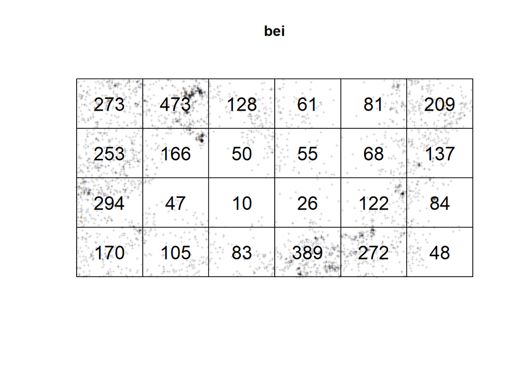

```r
Q24 <- quadratcount(bei, nx = 6, ny = 4)
plot(bei,  cex = 0.5, pch = "+")
plot(Q24, add = TRUE, cex = 1.5)
```

```r
quadrat.test(Q24)
```

```
    Chi-squared test of CSR using quadrat counts

data:
X2 = 2222, df = 23, p-value < 2.2e-16
alternative hypothesis: two.sided

Quadrats: 6 by 4 grid of tiles
```

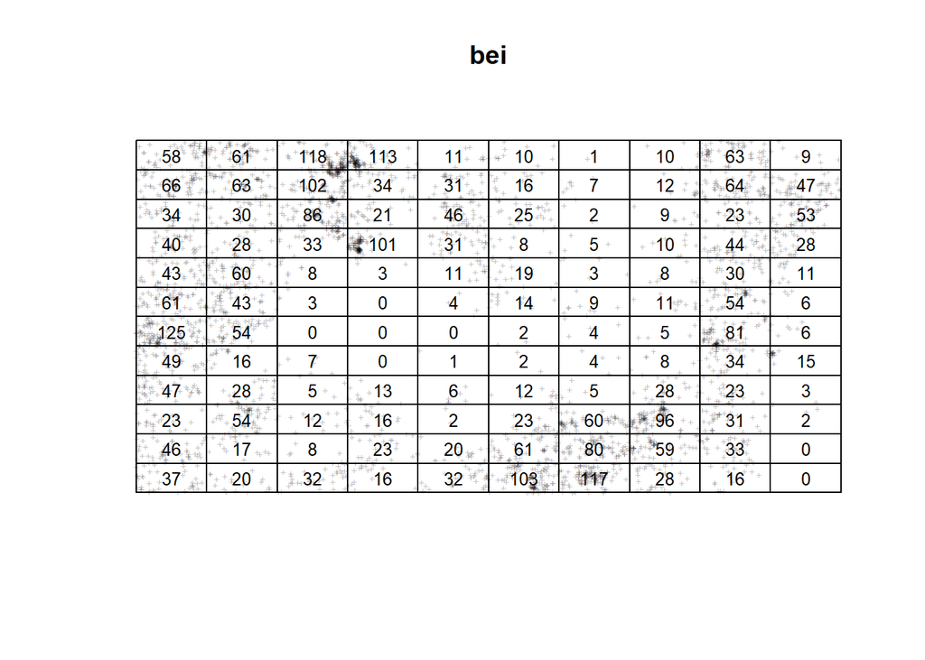

```r
Q120 <- quadratcount(bei, nx = 10, ny = 12)
plot(bei, use.marks = F, cex = 0.5, pch = "+")
plot(Q120, add = TRUE, cex = 0.8)
```

```r
quadrat.test(Q120)
```

```
    Chi-squared test of CSR using quadrat counts

data:
X2 = 3558.8, df = 119, p-value < 2.2e-16
alternative hypothesis: two.sided

Quadrats: 10 by 12 grid of tiles
```

También podemos calcular la **densidad** de puntos en cada cuadrado, en vez del número total:

```r
q_dens <- intensity(Q9)
q_dens
```

```
           x
y            [0,333) [333,667) [667,1e+03]
  [333,500] 0.017010  0.004230    0.006714
  [167,333) 0.008478  0.001242    0.004932
  [0,167)   0.006570  0.008964    0.006732
```

Y plotearlo:

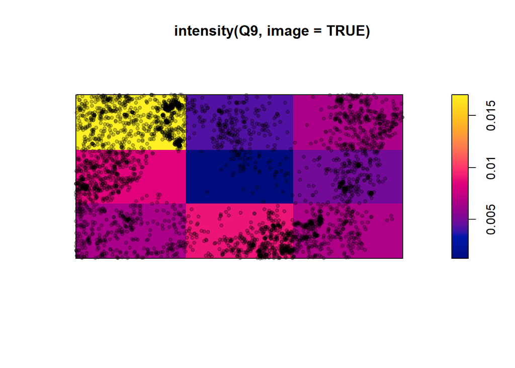

```r
plot(intensity(Q9, image=TRUE))
plot(bei, use.marks = F, pch=20, add=TRUE)
```

## Análisis de cuadrículas basadas en covariable

A menudo, más que dividir el terreno en un número de cuadrículas regulares, nos interesa dividirlo según alguna variable continua de interés, que pensemos que puede explicar la distribución. Ya comentamos que `spatstat` proporciona, junto con el dataset `bei`, otro llamado `bei.extra` que contiene los valores de altitud y pendiente en la misma parcela. Echémosles un vistazo:

```r
bei.extra
```

```
List of pixel images

elev:
real-valued pixel image
101 x 201 pixel array (ny, nx)
enclosing rectangle: [-2.5, 1002.5] x [-2.5, 502.5] metres

grad:
real-valued pixel image
101 x 201 pixel array (ny, nx)
enclosing rectangle: [-2.5, 1002.5] x [-2.5, 502.5] metres
```

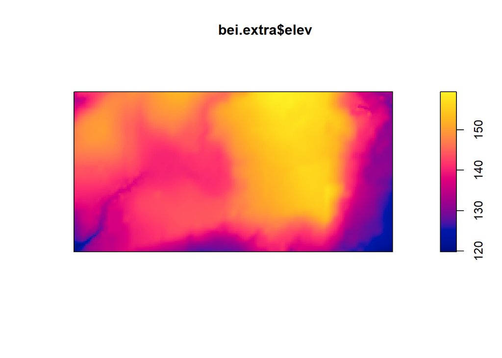

```r
plot(bei.extra$elev)
```

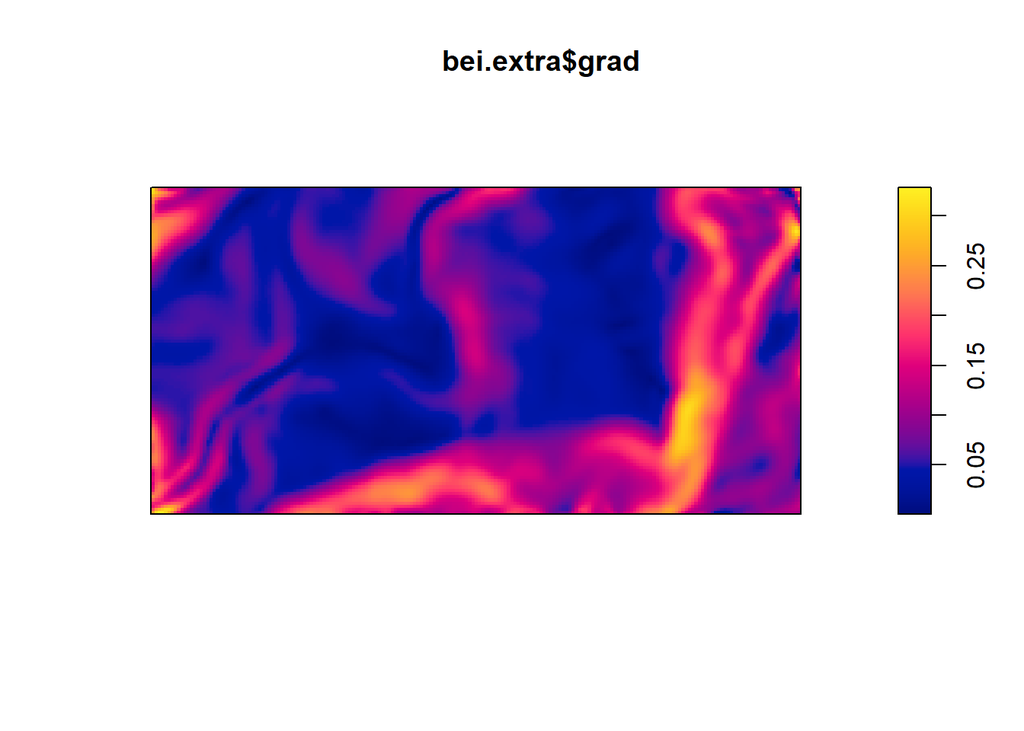

```r
plot(bei.extra$grad)
```

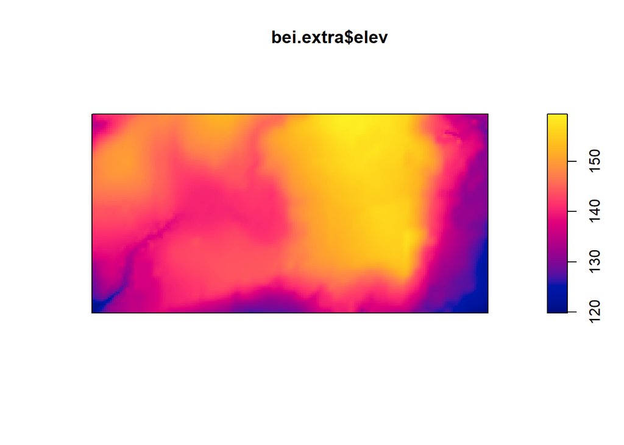

```r
plot(bei.extra$elev)
```

[output not shown]

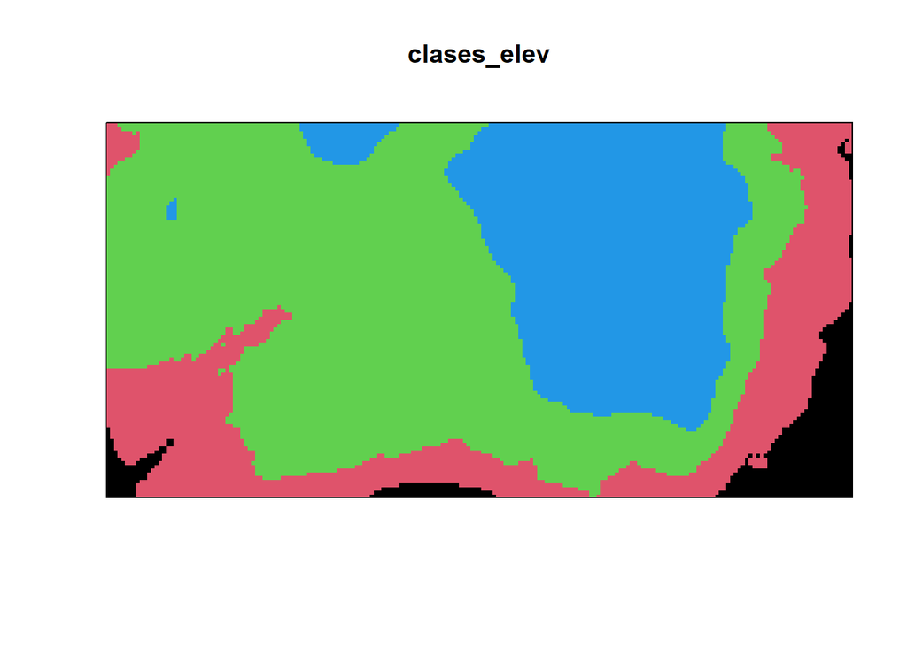

```r
clases_elev <- cut(bei.extra$elev, breaks = c( -Inf, 130, 140, 150, 160 , Inf),
              labels=1:5)  # Classify the raster
plot(clases_elev)
```

Ahora usamos de nuevo la función `quadratcount`. pero indicando que queremos “teselar” por las clases de elevación:

```r
Q_tes   <- quadratcount(bei, tess = clases_elev)
I_tes <- intensity(Q_tes)  # Compute density
I_tes
```

```
tile
          1           2           3           4
0.002415371 0.006514200 0.008701685 0.005409613
```

Estos números son el número de puntos por metro cuadrado en cada clase de elevación. Podemos visualizarlo como antes:

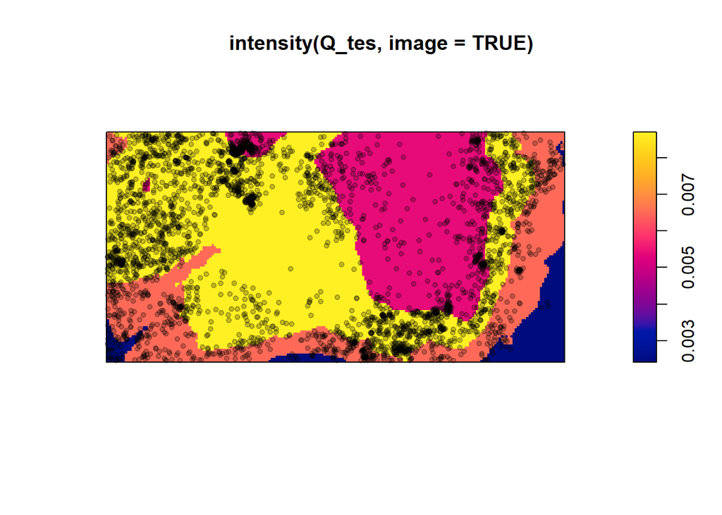

```r
plot(intensity(Q_tes, image=TRUE))
plot(bei, pch=20, add=TRUE)
```

Y también podemos realizar un test estadístico de este conteo:

```r
quadrat.test(Q_tes)
```

```
    Chi-squared test of CSR using quadrat counts

data:
X2 = 232.08, df = 3, p-value < 2.2e-16
alternative hypothesis: two.sided

Quadrats: 4 tiles (levels of a pixel image)
```

## Densidad en kernel

El recuento de cuadrículas es útil para caracterizar la intensidad de un proceso puntual no homogéneo, pero tiene sus limitaciones:

- La elección del origen, la orientación de las cuadrículas y el tamaño de los mismos afecta a la distribución de frecuencias observada, y no deja de ser una decisión arbitraria.
- Se pierde una cantidad significativa de información de detalle

Para evitar el problema podemos hacer un análisis mediante algoritmos KDE (kernel density estimation), que utilizan un enfoque de ventana móvil para caracterizar la intensidad. Este enfoque tiende a preservar una mayor cantidad de detalles espaciales y no sufre tanto por la elección del origen, la orientación y el tamaño de las cuadrículas.

El paquete `spatstat` tiene una función (`density`) que calcula un kernel a partir del patrón de puntos, y determina la densidad de puntos de cada celda del área de estudio según ese kernel.

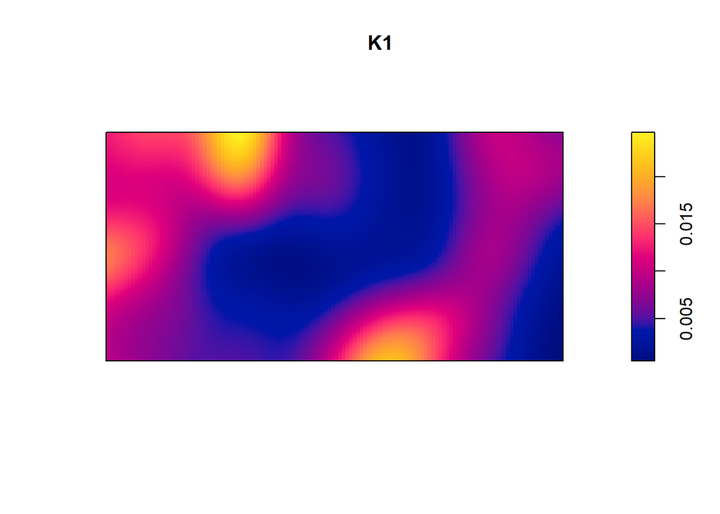

```r
K1 <- density(bei)
plot(K1)
```

Para mejorar la visualización podemos añadirles las isolíneas de densidad, y los puntos, para comprobar el resultado:

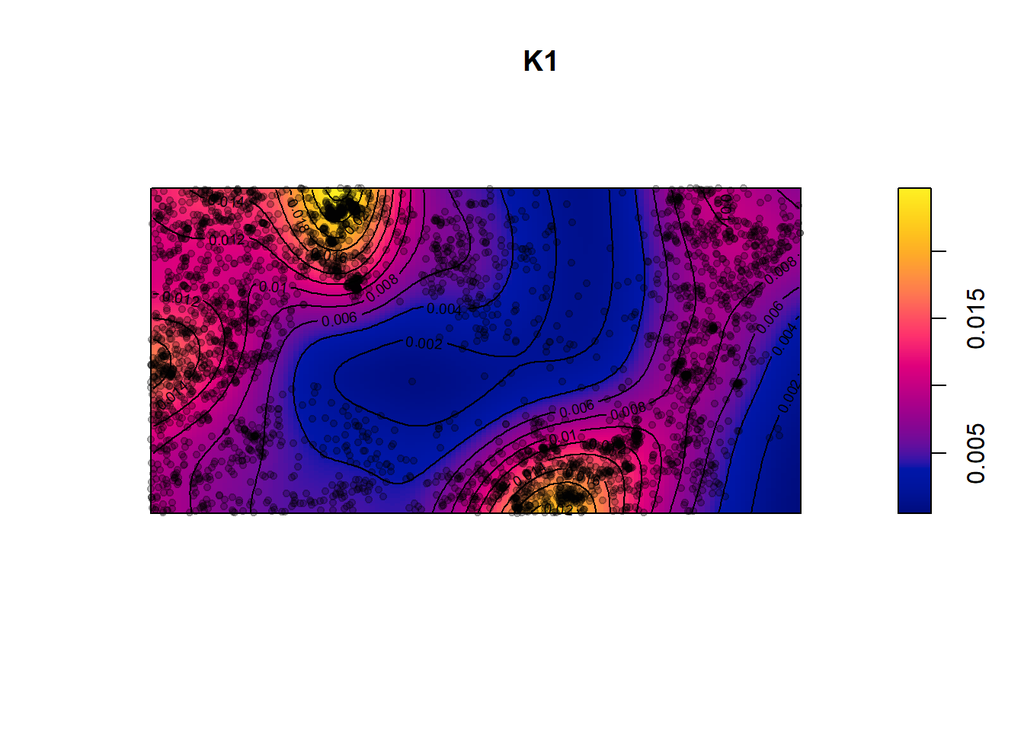

```r
plot(K1)
contour(K1, add=TRUE)
plot(bei, pch=20, add=TRUE)
```

El ancho de banda (es decir, el radio) de la función kernel se define automáticamente en función del área de estudio, pero se puede personalizar también, usando el parámetro `sigma`:

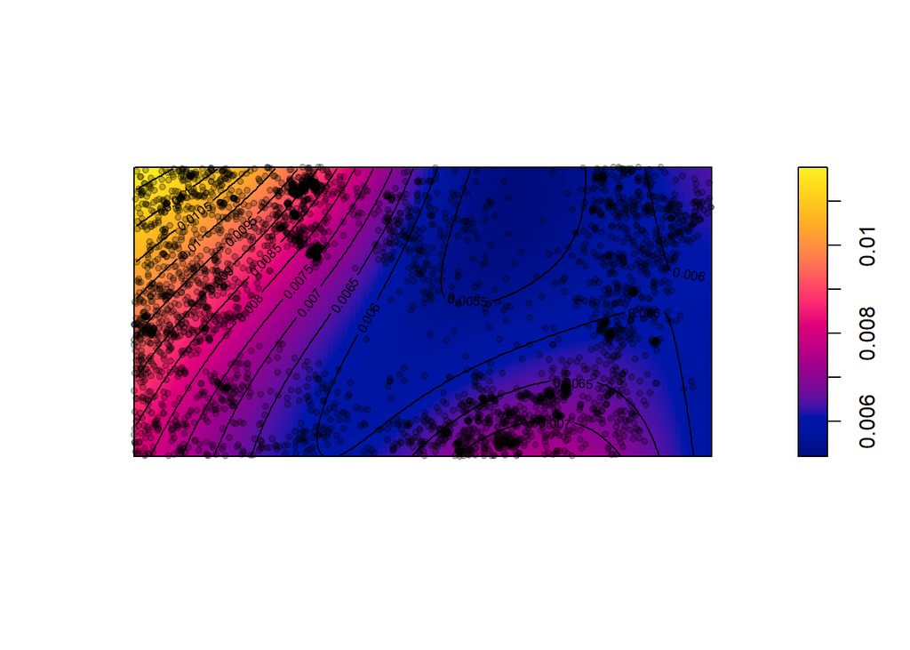

```r
K2 <- density(bei, sigma=200)
plot(K2, main=NULL)
contour(K2, add=TRUE)
plot(bei, pch=20, add=TRUE)
```

Antes hemos visto cómo crear cuadrículas en función de los valores de una covariable. Podemos aprovechar las funcionalidades de los cálculos de intensidad con kernel para determinar de manera directa si la intensidad de un proceso de patrón de puntos depende de alguna covariable. Podemos usar la función `rhohat()`, indicando qué dataset queremos analizar, y con qué variable se quiere evaluar:

```r
rhohat(bei, bei.extra$grad)
```

```
Intensity function estimate (class rhohat) for the covariate X
Function values are absolute intensities
Type of estimate: Smooth function of covariate
Estimation method: ratio of fixed-bandwidth kernel smoothers
    Actual smoothing bandwidth sigma =  0.010347
Pointwise 95% confidence bands for rho(x)
     based on asymptotic variance of rhohat(x)
Call: rhohat.ppp(bei, bei.extra$grad)

Function value object (class 'fv')
for the function X -> rho(X)
...........................................................................
    Math.label            Description
X   X                     Covariate X
rho hat(rho)(X)           Estimated intensity
ave bar(rho)              Average intensity
var bold(Var)~hat(rho)(X) Variance of estimator
hi  rho[hi](X)            Upper limit of pointwise 95%% confidence interval
lo  rho[lo](X)            Lower limit of pointwise 95%% confidence interval
...........................................................................
Default plot formula:  .~X
where "." stands for 'rho', 'ave', 'hi', 'lo'
Columns 'hi' and 'lo' will be plotted as shading (by default)
Recommended range of argument X: [0.00086958, 0.32846]
Available range of argument X: [0.00086958, 0.32846]
```

La salida de la función `rhohat()` no es muy clara, pero podemos plotearla:

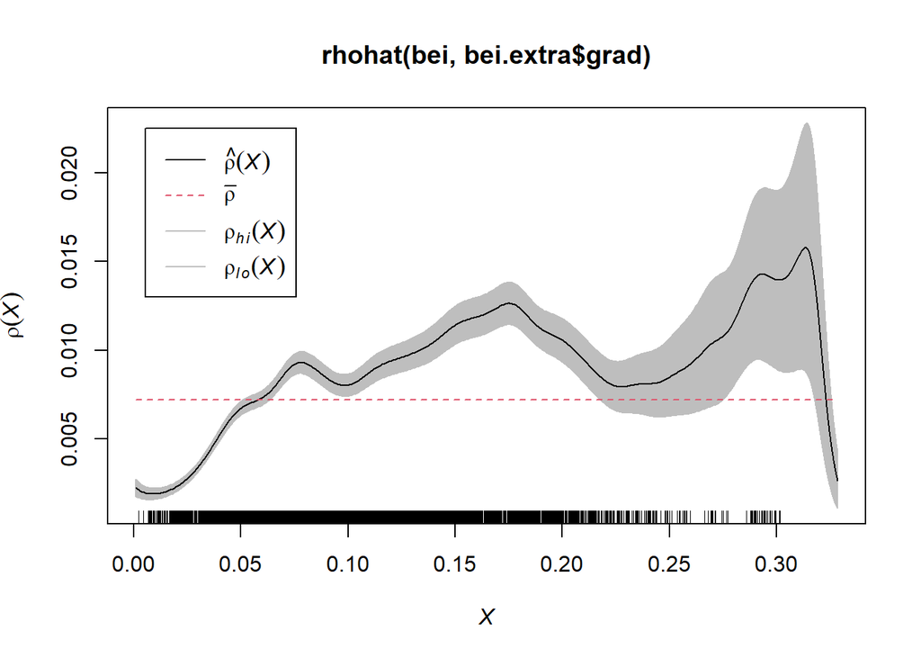

```r
plot(rhohat(bei, bei.extra$grad))
```

El plot es una estimación de la intensidad en función de la pendiente del terreno. Indica que es más infrecuente encontrar árboles en terrenos llanos (pendiente < 0.05) que en zonas de pendientes más altas. La linea negra $\rho$ es la intensidad estimada, mientras que la región en gris representa el intervalo de confianza.

# Análisis basados en la distancia

Los análisis basados en la distancia están relacionados con las propiedades de segundo orden de los puntos, es decir, con la dependencia espacial entre ellos. Existen varios métodos, que evaluaremos de nuevo sobre el fichero `bei`:

## Vecinos más próximos (ANN)

Podemos calcular la distancia entre cada árbol y su vecino más próximo, usando `nndist()` y fijando `k = 1` (para extraer la distancia al más próximo), y calculamos la media de todas las distancias:

```r
dist1 <- nndist(bei, k=1)
head(dist1)
```

```
[1] 0.2236068 0.9848858 3.3241540 8.0777472 5.8137767 5.9203040
```

```r
mean(dist1)
```

```
[1] 4.329677
```

También podemos calcularlo con el segundo vecino de cada árbol, o con el tercero, o el n-ésimo…

```r
mean(nndist(bei, k=2))
```

```
[1] 6.473149
```

```r
mean(nndist(bei, k=3))
```

```
[1] 8.120378
```

```r
mean(nndist(bei, k=15))
```

```
[1] 19.64182
```

Con una función podemos calcular NN para cualquier valor de vecino deseado, y luego calcular la media:

```r
ANN <- apply(nndist(bei, k=1:200),2,FUN=mean)
```

Después ploteamos la distancia media al vecino k-ésimo, que nos da información sobre cómo se distribuyen los puntos.

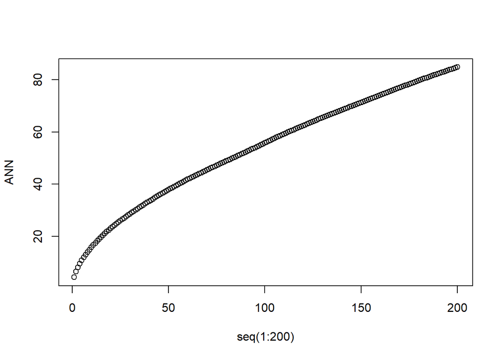

```r
plot(seq(1:200), ANN)
```

## Función $G$ y función $F$

Podemos realizar un test más formal de cómo varía la distancia al vecino más próximo, usando la función `G(r)`, que calcula la distribución acumulada de la distancia de un punto cualquiera `x` a su punto más próximo. El valor de $G(r)$ es la proporción de puntos que tienen su vecino más cercano a una distancia igual o inferior a $r$. Esta función viene implementada en `spatstat` como `Gest()`:

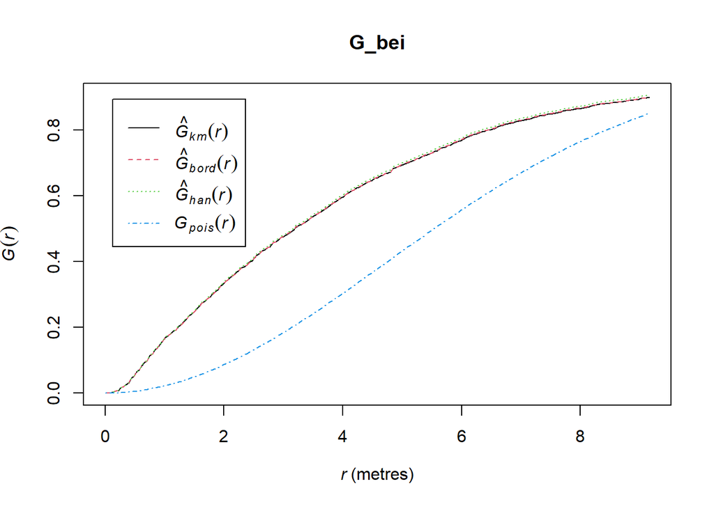

```r
G_bei <- Gest(bei)
plot(G_bei)
```

El comando de arriba produce un gráfico que compara la función *G* observada o empírica y la esperada si la distribución fuera aleatoria (linea azul). En este caso, los valores empíricos son muy superiores, lo que indica agrupación en los puntos.

Para poder saber si las diferencias entre la función empírica y la teórica son significativas (es decir, si realmente podemos rechazar que los puntos se distribuyan al azar), podemos usar la función `envelope()`. Esta función genera un número de muestras con la misma cantidad de puntos pero distribución aleatoria, y compara nuestra muestra a ellas.

```r
g_bei_env <- envelope(bei, Gest, nsim = 100)
```

```
Generating 100 simulations of CSR  ...
1, 2, 3, 4, 5, 6, 7, 8, 9, 10, 11, 12, 13, 14, 15, 16, 17, 18, 19, 20,
21, 22, 23, 24, 25, 26, 27, 28, 29, 30, 31, 32, 33, 34, 35, 36, 37, 38, 39, 40,
41, 42, 43, 44, 45, 46, 47, 48, 49, 50, 51, 52, 53, 54, 55, 56, 57, 58, 59, 60,
61, 62, 63, 64, 65, 66, 67, 68, 69, 70, 71, 72, 73, 74, 75, 76, 77, 78, 79, 80,
81, 82, 83, 84, 85, 86, 87, 88, 89, 90, 91, 92, 93, 94, 95, 96, 97, 98, 99,
100.

Done.
```

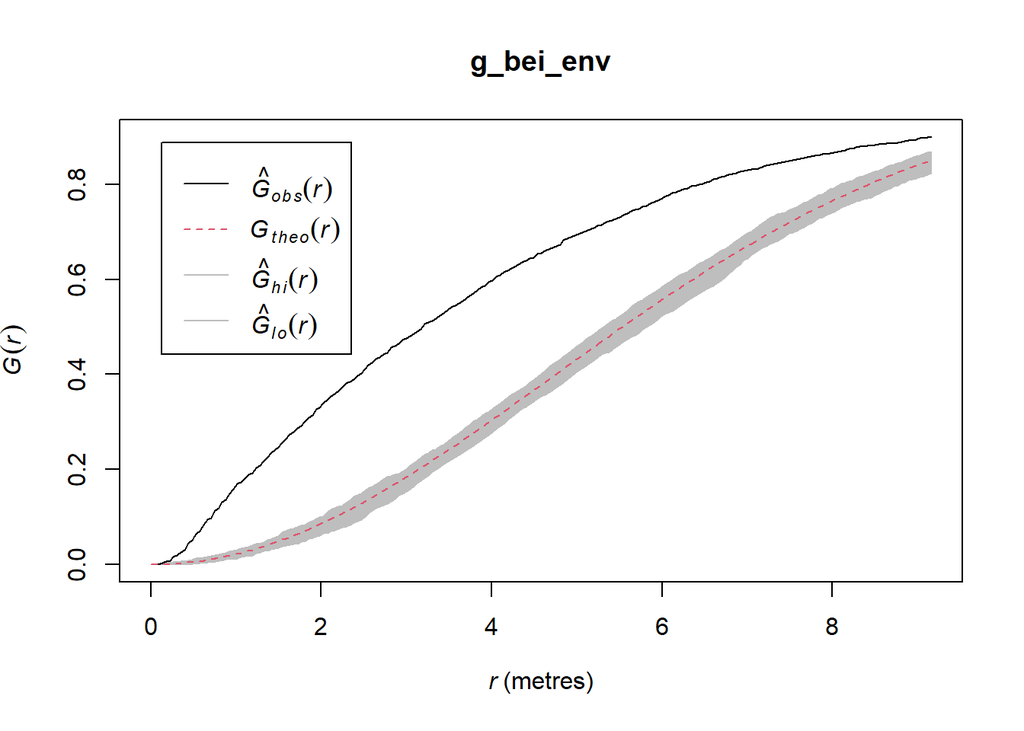

```r
plot(g_bei_env)
```

Vemos que ahora se ha representado una banda gris alrededor de la función G teórica, que indica el intervalo de confianza generado a partir de las 100 simulaciones que hemos realizado (`nsim = 100`)

De manera análoga, la función `F` representa la frecuencia acumulada de la distancia más corta entre un punto y un conjunto de puntos aleatoriamente localizados en el área de estudio:

```r
f_bei_env <- envelope(bei, Fest, nsim = 100)
```

```
Generating 100 simulations of CSR  ...
1, 2, 3, 4, 5, 6, 7, 8, 9, 10, 11, 12, 13, 14, 15, 16, 17, 18, 19, 20,
21, 22, 23, 24, 25, 26, 27, 28, 29, 30, 31, 32, 33, 34, 35, 36, 37, 38, 39, 40,
41, 42, 43, 44, 45, 46, 47, 48, 49, 50, 51, 52, 53, 54, 55, 56, 57, 58, 59, 60,
61, 62, 63, 64, 65, 66, 67, 68, 69, 70, 71, 72, 73, 74, 75, 76, 77, 78, 79, 80,
81, 82, 83, 84, 85, 86, 87, 88, 89, 90, 91, 92, 93, 94, 95, 96, 97, 98, 99,
100.

Done.
```

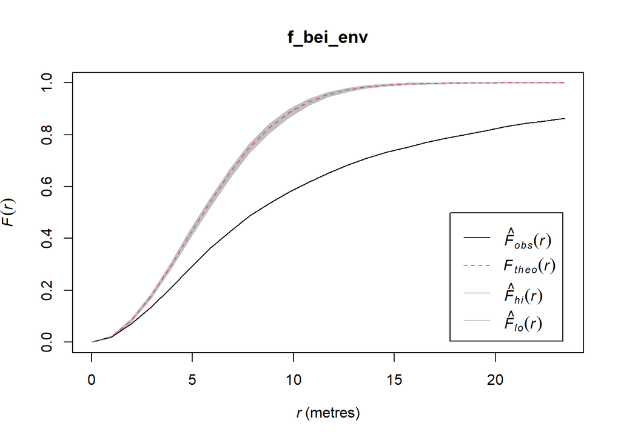

```r
plot(f_bei_env)
```

En este caso, valores más altos que los teóricos indican patrones regulares (mayor distancia entre puntos), mientras que los más bajos indican agrupación. Como la linea observada va muy por debajo de la teórica, podemos concluir que nuestros puntos están agrupados.

## Función $K$ y función $L$

La función $K$ calcula, para una serie de bandas concéntricas a cada punto de la muestra, el número de puntos que cae dentro de la banda. Esto nos da un valor de $K$ para cada distancia, valor que siempre debe aumentar con la distancia. Para calcular la función $K$ podemos usar la función de R `Kest()`:

```r
K <- Kest(bei)
```

```
number of data points exceeds 3000 - computing border correction estimate only
```

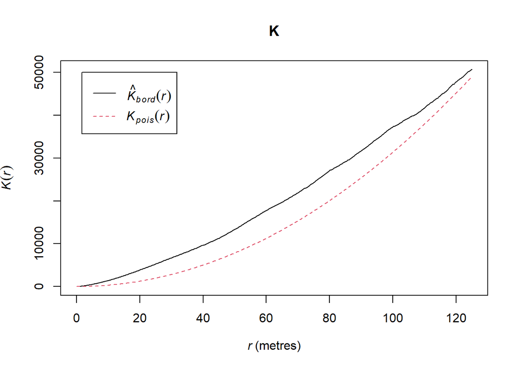

```r
plot(K)
```

En este caso, la curva por encima de la teórica (Poisson) indica agrupación de puntos. Podemos calcular el intervalo de confianza igual que hemos hecho antes:

```r
k_bei_env <- envelope(bei, Kest, nsim = 30)
```

```
Generating 30 simulations of CSR  ...
1, 2, 3, 4, 5, 6, 7, 8, 9, 10, 11, 12, 13, 14, 15, 16, 17, 18, 19, 20,
21, 22, 23, 24, 25, 26, 27, 28, 29,
30.

Done.
```

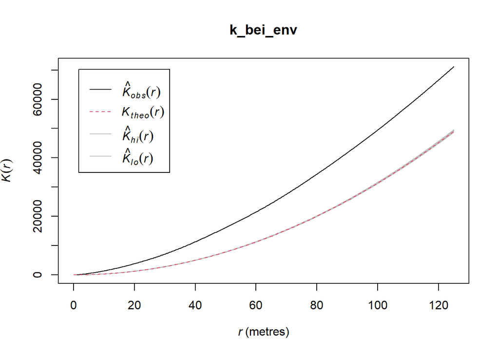

```r
plot(k_bei_env)
```

La función $L$, que es sólo una modificación de $K$, se calcula fácilmente, casi de la misma manera:

```r
L <- Lest(bei)
```

```
number of data points exceeds 3000 - computing border correction estimate only
```

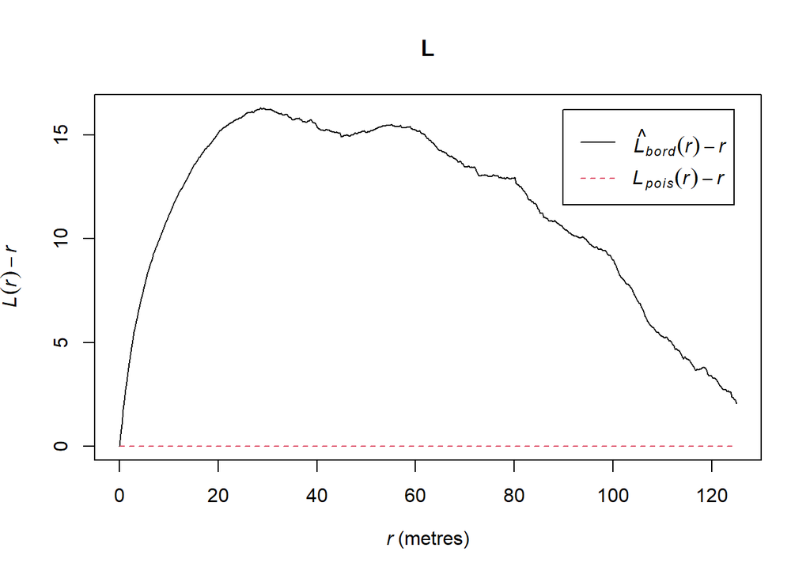

```r
plot(L, . -r ~ r)
```

```r
L_bei_env <- envelope(bei, Lest, nsim = 99)
```

```
Generating 99 simulations of CSR  ...
1, 2, 3, 4, 5, 6, 7, 8, 9, 10, 11, 12, 13, 14, 15, 16, 17, 18, 19, 20,
21, 22, 23, 24, 25, 26, 27, 28, 29, 30, 31, 32, 33, 34, 35, 36, 37, 38, 39, 40,
41, 42, 43, 44, 45, 46, 47, 48, 49, 50, 51, 52, 53, 54, 55, 56, 57, 58, 59, 60,
61, 62, 63, 64, 65, 66, 67, 68, 69, 70, 71, 72, 73, 74, 75, 76, 77, 78, 79, 80,
81, 82, 83, 84, 85, 86, 87, 88, 89, 90, 91, 92, 93, 94, 95, 96, 97, 98,
99.

Done.
```

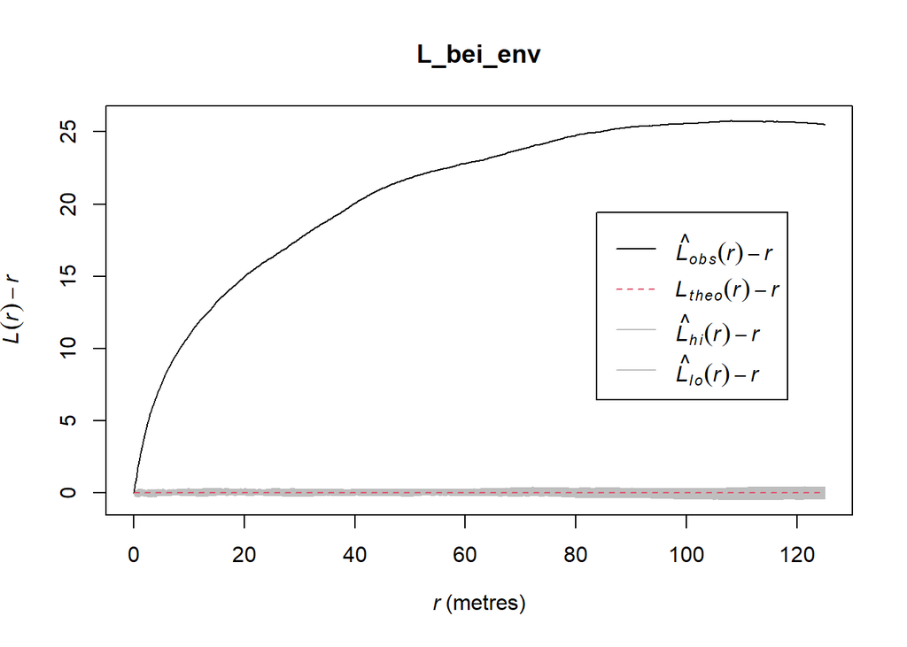

```r
plot(L_bei_env, . -r ~ r)
```

## Función de correlación de pares

La función de correlación de pares no es más que una version modificada de K en la que se hacen bandas anulares concéntricas.

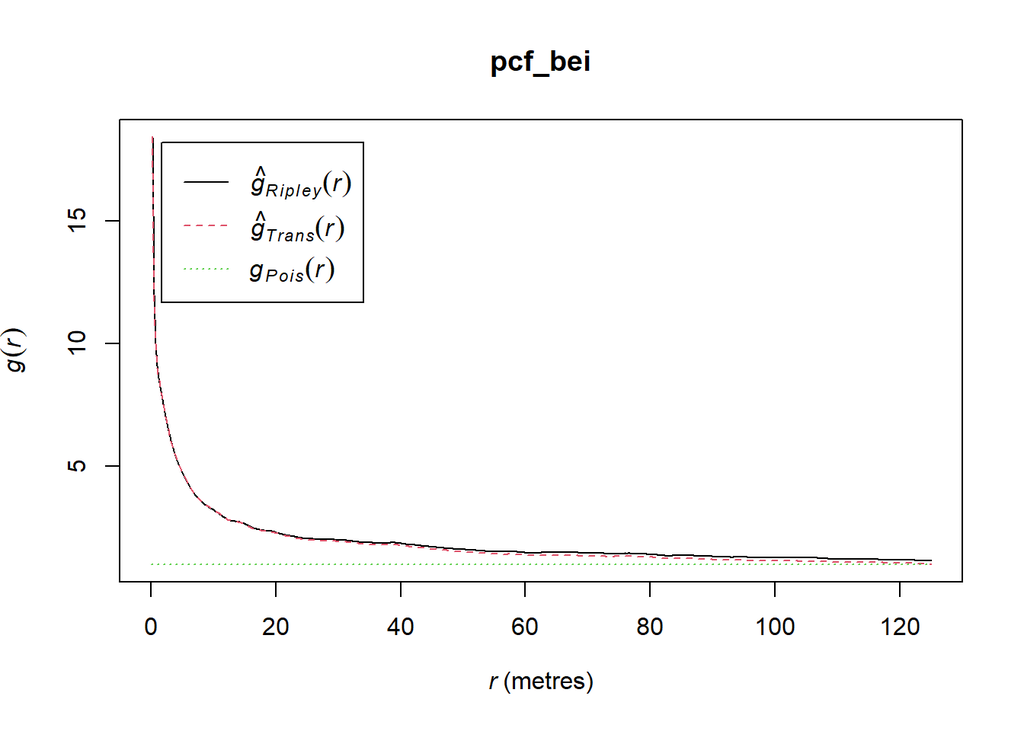

```r
pcf_bei  <- pcf(bei)
plot(pcf_bei)
```

```r
pcf_bei_env <- envelope(bei, pcf, nsim = 10)
```

```
Generating 10 simulations of CSR  ...
1, 2, 3, 4, 5, 6, 7, 8, 9,
10.

Done.
```

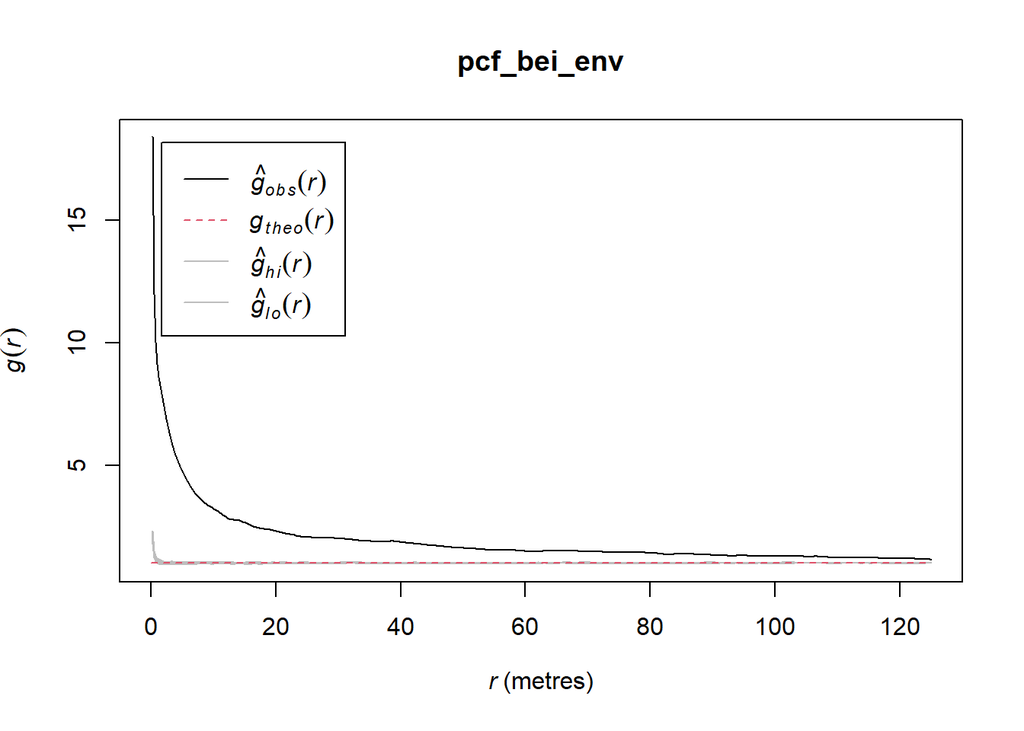

```r
plot(pcf_bei_env)
```